**Retail Marketing Individual Assignment**

**Analysis notebook**

Data preparation, feature engineering and regression modelling.

# Imports

```python
import re
import pandas as pd
import numpy as np
import scipy

import calendar

import statsmodels.api as sm
from statsmodels.tsa.seasonal import seasonal_decompose
from statsmodels.nonparametric.smoothers_lowess import  lowess

from sklearn.model_selection import train_test_split
from sklearn.metrics import mean_squared_error

from IPython.core.display import display, Markdown, Latex, HTML

import warnings; warnings.simplefilter('ignore')
```

```python
#visualisation libraries
import matplotlib.pyplot as plt
import matplotlib as mpl
import seaborn as sns

#matplotlib styling
plt.rcParams['font.family'] = 'serif'
```

```python
pd.set_option('display.max_columns', 500)
```

**Custom Python Files**

Please see `constants.py` and `utils.py` for custom functions. All constants from `constants.py` are in upper case

```python
%load_ext autoreload
%autoreload 2
```

```python
#custom python files
from utils import *
from constants import *
```

# Load Data

The data covers weekly sales, price, display and feature information for three brands of beer for the supermarket chain Dominicks over 227 weeks.

Retailer margin and wholesale price for each brand is also included.

```python
data = pd.read_excel(f"{DATA_FOLDER}/01_raw/beer_data_chicago_Dominicks.xlsx", index_col='Week ')
```

**Add unit sales**

```python
brand_sales_cols = ['SALESBRAND1','SALESBRAND2','SALESBRAND3']
brand_price_cols = ['PRICEBRAND1','PRICEBRAND2','PRICEBRAND3']


#calculate units (round to nearest integer)
for s,p in zip(brand_sales_cols,brand_price_cols):
    data[f"UNITSBRAND{s[-1]}"] = (data[s]/data[p]).astype(int)
```

**Add timeseries dates**

The data is a time series. Currently the weeks are expressed as a incrementing series from 1 to 227. In the [literature](https://pubsonline.informs.org/doi/10.1287/mnsc.1040.0225) it is stated that the dataset begins in June 1989. It will be assumed that the data starts from week 1 (starting on a Sunday) of June 1989. Therefore the index will be converted to the actual dates and new column will be added to the dataset which describes the month of the year (this will be important for incorporating seasonality into the model).

```python
# convert index to datetime
data.index = pd.date_range(start='1989/06/01', periods=len(data), freq='W')
data['month'] = data.index.month_name()
```

**Final data**

```python
#assert no missing data
assert data.isnull().sum().sum() == 0

print(f"There are {data.shape[0]} datapoints")
data.head()
```

```
There are 227 datapoints
```

|  | CategorySales | PRICEBRAND1 | PRICEBRAND2 | PRICEBRAND3 | display_brand1 | display_brand2 | display_brand3 | FEATUREBRAND1 | FEATUREBRAND2 | FEATUREBRAND3 | RETAILERMARGINBRAND1 | RETAILERMARGINBRAND2 | RETAILERMARGINBRAND3 | SALESBRAND1 | SALESBRAND2 | SALESBRAND3 | WHOLESALEPRICE1 | WHOLESALEPRICE2 | WHOLESALEPRICE3 | UNITSBRAND1 | UNITSBRAND2 | UNITSBRAND3 | month |
| --- | --- | --- | --- | --- | --- | --- | --- | --- | --- | --- | --- | --- | --- | --- | --- | --- | --- | --- | --- | --- | --- | --- | --- |
| 1989-06-04 | 62929.477667 | 5.005623 | 4.562936 | 4.293051 | 0.000 | 0.124 | 0.092 | 0.0 | 0.0 | 0.0 | 0.120878 | 0.136304 | 0.156036 | 24321.600000 | 27790.157667 | 10817.720000 | 4.011377 | 4.323338 | 3.623182 | 4858 | 6090 | 2519 | June |
| 1989-06-11 | 70907.531666 | 4.759082 | 4.666338 | 4.342844 | 0.234 | 0.075 | 0.089 | 0.0 | 0.0 | 0.0 | 0.135090 | 0.089354 | 0.157650 | 33005.983333 | 26466.924333 | 11434.624000 | 4.035964 | 4.333838 | 3.658193 | 6935 | 5671 | 2632 | June |
| 1989-06-18 | 67031.204999 | 4.630858 | 4.770684 | 4.913317 | 0.256 | 0.119 | 0.044 | 0.0 | 0.0 | 0.0 | 0.119915 | 0.081313 | 0.123846 | 34129.983333 | 26000.576333 | 6900.645333 | 4.198608 | 4.254309 | 4.304820 | 7370 | 5450 | 1404 | June |
| 1989-06-25 | 83289.667166 | 4.222040 | 4.266464 | 4.934866 | 0.105 | 0.120 | 0.016 | 0.0 | 0.0 | 0.0 | 0.129831 | 0.166255 | 0.131854 | 41453.750000 | 35708.431833 | 6127.485333 | 3.712543 | 3.520105 | 4.284186 | 9818 | 8369 | 1241 | June |
| 1989-07-02 | 122057.548834 | 4.105199 | 4.103394 | 4.905153 | 0.180 | 0.092 | 0.000 | 0.0 | 0.0 | 0.0 | 0.133630 | 0.124810 | 0.130308 | 67620.016667 | 46842.793500 | 7594.738667 | 3.555056 | 3.592828 | 4.265970 | 16471 | 11415 | 1548 | July |

# Exploratory Data Analysis

## Dataset characteristics

The main features of the dataset available for modelling include ([Srinivasan et. al, 2002](https://pubsonline.informs.org/doi/10.1287/mnsc.1040.0225)):

- PRICEBRAND*: the average price of the beer brand during the week
- display_brand*: the percentage of stock keeping units which were put on display
- FEATUREBRAND*: the percentage of stock keeping units which were 'featured' during the week
- REATAILERMARGINBRAND*: the percentage profit (margin) the retailer made on the sale of each product
- SALESBRAND*: the sales in dollars (\$)
- WHOLESALEPRICE*: the wholesale price of the product
- UNITSBRAND*: the number of units sold in each week

```python
#descriptive statistics for the dataframe
data.describe().T
```

|  | count | mean | std | min | 25% | 50% | 75% | max |
| --- | --- | --- | --- | --- | --- | --- | --- | --- |
| CategorySales | 227.0 | 62567.408851 | 18223.926584 | 37429.139167 | 49491.279833 | 58811.270167 | 70813.822832 | 146302.515499 |
| PRICEBRAND1 | 227.0 | 4.756340 | 0.243022 | 4.104838 | 4.592634 | 4.767329 | 4.922494 | 5.325438 |
| PRICEBRAND2 | 227.0 | 4.536854 | 0.329527 | 3.221186 | 4.347520 | 4.519291 | 4.743886 | 5.408419 |
| PRICEBRAND3 | 227.0 | 4.644886 | 0.258895 | 3.882713 | 4.466815 | 4.643807 | 4.849372 | 5.152313 |
| display_brand1 | 227.0 | 0.182921 | 0.091583 | 0.000000 | 0.121500 | 0.172000 | 0.245500 | 0.499000 |
| display_brand2 | 227.0 | 0.119185 | 0.034654 | 0.029000 | 0.093500 | 0.118000 | 0.139000 | 0.242000 |
| display_brand3 | 227.0 | 0.135416 | 0.092158 | 0.000000 | 0.063500 | 0.134000 | 0.197000 | 0.461000 |
| FEATUREBRAND1 | 227.0 | 0.007533 | 0.022433 | 0.000000 | 0.000000 | 0.000000 | 0.001000 | 0.128000 |
| FEATUREBRAND2 | 227.0 | 0.002048 | 0.004879 | 0.000000 | 0.000000 | 0.000000 | 0.001000 | 0.027000 |
| FEATUREBRAND3 | 227.0 | 0.001238 | 0.009878 | 0.000000 | 0.000000 | 0.000000 | 0.000000 | 0.116000 |
| RETAILERMARGINBRAND1 | 227.0 | 0.083540 | 0.056322 | -0.149657 | 0.062554 | 0.101008 | 0.122842 | 0.167088 |
| RETAILERMARGINBRAND2 | 227.0 | 0.084683 | 0.044466 | -0.108038 | 0.063538 | 0.087844 | 0.114351 | 0.166255 |
| RETAILERMARGINBRAND3 | 227.0 | 0.105836 | 0.043696 | -0.088170 | 0.084829 | 0.105744 | 0.138338 | 0.171128 |
| SALESBRAND1 | 227.0 | 28437.936013 | 10034.785970 | 13251.850000 | 21827.841666 | 26561.866667 | 31881.425000 | 70455.333333 |
| SALESBRAND2 | 227.0 | 27128.381348 | 9294.187657 | 9696.835167 | 21468.204500 | 24291.645833 | 29992.384417 | 82778.940500 |
| SALESBRAND3 | 227.0 | 7001.091489 | 2232.474723 | 3236.733333 | 5339.552000 | 6851.533333 | 8302.037333 | 20276.800000 |
| WHOLESALEPRICE1 | 227.0 | 4.148953 | 0.285246 | 3.289759 | 3.922661 | 4.141235 | 4.393710 | 4.871506 |
| WHOLESALEPRICE2 | 227.0 | 4.138844 | 0.147396 | 3.520105 | 4.047587 | 4.150454 | 4.244239 | 4.529524 |
| WHOLESALEPRICE3 | 227.0 | 4.144181 | 0.132737 | 3.620668 | 4.091130 | 4.132447 | 4.235407 | 4.533123 |
| UNITSBRAND1 | 227.0 | 6054.365639 | 2391.084993 | 2610.000000 | 4501.000000 | 5533.000000 | 6736.000000 | 16471.000000 |
| UNITSBRAND2 | 227.0 | 6127.070485 | 2785.649929 | 2022.000000 | 4548.500000 | 5359.000000 | 6733.500000 | 25698.000000 |
| UNITSBRAND3 | 227.0 | 1529.242291 | 558.126336 | 637.000000 | 1124.500000 | 1500.000000 | 1845.000000 | 5222.000000 |

## Dataset features

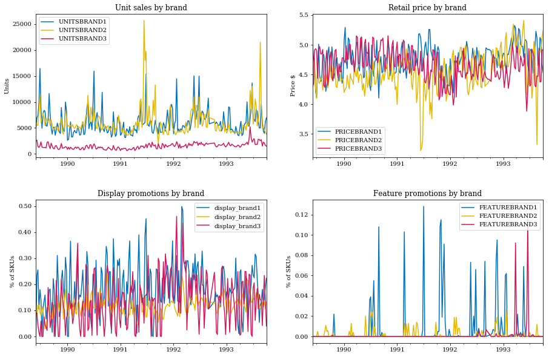

```python
cols = data.columns
brand_units_cols = get_cols(r"UNITS", cols)
brand_price_cols = get_cols(r"^PRICE", cols)
brand_display_cols = get_cols(r"display", cols)
brand_feature_cols = get_cols(r"FEATURE", cols)
brand_wholesale_cols = get_cols(r"WHOLESALE", cols)


fig, axs = plt.subplots(nrows=2,ncols=2,figsize=(15,10))

axs[0][0] = plot_cols(data, brand_units_cols, axs[0][0], "Unit sales by brand", "Units", y_decimal=0)
axs[0][1] = plot_cols(data, brand_price_cols, axs[0][1], "Retail price by brand", "Price $", y_decimal=1)
axs[1][0] = plot_cols(data, brand_display_cols, axs[1][0], "Display promotions by brand", "% of SKUs", y_decimal=2)
axs[1][1] = plot_cols(data, brand_feature_cols, axs[1][1], "Feature promotions by brand", "% of SKUs", y_decimal=2)


plt.subplots_adjust(hspace=0.3)

plt.savefig(f"{VISUALISATION_FOLDER}/eda_plots.png")
plt.show()
```

The SCAN*PRO model is sensitive to bias in the estimated parameters if the variables are endogenous. For example, the price coefficient may be biased if store managers set their prices based on the level of sales of the product. If this is the case an instrumental variable approach can be taken using wholesale prices instead which are not controlled by the manager.

The potential endogeneity problem will be investigated later in the analysis if required.

[figure not shown]

```python
fig, ax = plt.subplots(nrows=1, figsize=(7,5))
plot_cols(data, brand_wholesale_cols, ax, title='Brand Wholesale Prices',ylabel='$')
plt.show()
```

## Seasonality

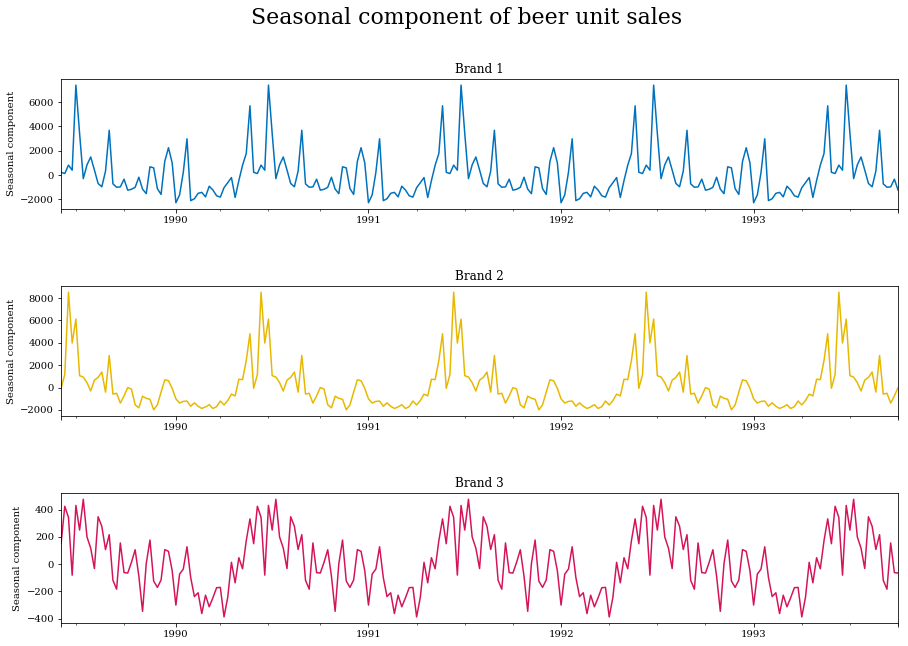

```python
brand1_seasonality = seasonal_decompose(data['UNITSBRAND1'], model='additive', period=52)
brand2_seasonality = seasonal_decompose(data['UNITSBRAND2'], model='additive', period=52)
brand3_seasonality = seasonal_decompose(data['UNITSBRAND3'], model='additive', period=52)

seasonal_results = [brand1_seasonality,brand2_seasonality,brand3_seasonality]


fig, axs = plt.subplots(3,1, figsize=(15,10))

for i, (result, ax) in enumerate(zip(seasonal_results,axs)):
    result.seasonal.plot(ax=ax, color=BRAND_COLORS[i])
    ax.set_title(f"Brand {i+1}")
    ax.set_ylabel("Seasonal component")

plt.suptitle("Seasonal component of beer unit sales", y=0.98, fontsize=22)

plt.subplots_adjust(hspace=0.6)
plt.savefig(f"{VISUALISATION_FOLDER}/seasonal_plots.png")
plt.show()
```

All three brands exhibit a significant seasonal impact on unit sales. This will need to be incorporated into the regression model.

Sales of beer are much higher in the summer months (May-September) compared to the winter months. There also appears to be a small peak in November/December each year probably as a result of the Thanksgiving/Christmas holiday season.

# Data Preparation

Cleaning and transforming the data for modelling.

The SCAN*PRO model is a multiplicative model, however, the parameters can be log transformed to create a linear model which is easier to estimate.

Following the EDA, a series of new/transformed features will be added to the dataset to be used in the regression model. Subsets of these features will be chosen for the final regression model:

1. A log transformation will be applied to each column so the model can be expressed as a linear function. Note that due to the presence of zero values, a log(x+1) transformation will be applied.
2. Seasonal dummy variables will be added to account for the seasonality in the unit sales
3. The 'FEATUREDBRAND*' columns will be converted into a binary variable as most of the values are zero

## Log Transformation

```python
#apply log transofation to all numeric columns
log_transform = data.select_dtypes(exclude='object').apply(lambda x: np.log(x+1),axis=1)

#add 'log_' prefix to column names
log_transform = log_transform.add_prefix('log_')

#add log_ columns to the dataset
data[log_transform.columns] = log_transform
```

## Seasonal Dummy Variables

```python
#drop one dummy variable
data = pd.get_dummies(data, columns=['month'],drop_first=True, prefix='', prefix_sep='')
```

## Binary Variables

```python
binary_col_names = ['binary_' + col for col in brand_feature_cols]
binary_col_names
```

```
['binary_FEATUREBRAND1', 'binary_FEATUREBRAND2', 'binary_FEATUREBRAND3']
```

```python
data[binary_col_names] = data[brand_feature_cols].applymap(lambda x: 1 if x>0.01 else 0)
```

```python
data.head(10)
```

|  | CategorySales | PRICEBRAND1 | PRICEBRAND2 | PRICEBRAND3 | display_brand1 | display_brand2 | display_brand3 | FEATUREBRAND1 | FEATUREBRAND2 | FEATUREBRAND3 | RETAILERMARGINBRAND1 | RETAILERMARGINBRAND2 | RETAILERMARGINBRAND3 | SALESBRAND1 | SALESBRAND2 | SALESBRAND3 | WHOLESALEPRICE1 | WHOLESALEPRICE2 | WHOLESALEPRICE3 | UNITSBRAND1 | UNITSBRAND2 | UNITSBRAND3 | log_CategorySales | log_PRICEBRAND1 | log_PRICEBRAND2 | log_PRICEBRAND3 | log_display_brand1 | log_display_brand2 | log_display_brand3 | … |
| --- | --- | --- | --- | --- | --- | --- | --- | --- | --- | --- | --- | --- | --- | --- | --- | --- | --- | --- | --- | --- | --- | --- | --- | --- | --- | --- | --- | --- | --- | --- |
| 1989-06-04 | 62929.477667 | 5.005623 | 4.562936 | 4.293051 | 0.000 | 0.124 | 0.092 | 0.0 | 0.000 | 0.0 | 0.120878 | 0.136304 | 0.156036 | 24321.600000 | 27790.157667 | 10817.720000 | 4.011377 | 4.323338 | 3.623182 | 4858 | 6090 | 2519 | 11.049786 | 1.792696 | 1.716126 | 1.666395 | 0.000000 | 0.116894 | 0.088011 | … |
| 1989-06-11 | 70907.531666 | 4.759082 | 4.666338 | 4.342844 | 0.234 | 0.075 | 0.089 | 0.0 | 0.000 | 0.0 | 0.135090 | 0.089354 | 0.157650 | 33005.983333 | 26466.924333 | 11434.624000 | 4.035964 | 4.333838 | 3.658193 | 6935 | 5671 | 2632 | 11.169146 | 1.750778 | 1.734543 | 1.675758 | 0.210261 | 0.072321 | 0.085260 | … |
| 1989-06-18 | 67031.204999 | 4.630858 | 4.770684 | 4.913317 | 0.256 | 0.119 | 0.044 | 0.0 | 0.000 | 0.0 | 0.119915 | 0.081313 | 0.123846 | 34129.983333 | 26000.576333 | 6900.645333 | 4.198608 | 4.254309 | 4.304820 | 7370 | 5450 | 1404 | 11.112928 | 1.728262 | 1.752791 | 1.777207 | 0.227932 | 0.112435 | 0.043059 | … |
| 1989-06-25 | 83289.667166 | 4.222040 | 4.266464 | 4.934866 | 0.105 | 0.120 | 0.016 | 0.0 | 0.000 | 0.0 | 0.129831 | 0.166255 | 0.131854 | 41453.750000 | 35708.431833 | 6127.485333 | 3.712543 | 3.520105 | 4.284186 | 9818 | 8369 | 1241 | 11.330092 | 1.652888 | 1.661359 | 1.780845 | 0.099845 | 0.113329 | 0.015873 | … |
| 1989-07-02 | 122057.548834 | 4.105199 | 4.103394 | 4.905153 | 0.180 | 0.092 | 0.000 | 0.0 | 0.000 | 0.0 | 0.133630 | 0.124810 | 0.130308 | 67620.016667 | 46842.793500 | 7594.738667 | 3.555056 | 3.592828 | 4.265970 | 16471 | 11415 | 1548 | 11.712256 | 1.630259 | 1.629906 | 1.775825 | 0.165514 | 0.088011 | 0.000000 | … |
| 1989-07-09 | 79422.435333 | 4.630080 | 4.727706 | 4.437782 | 0.141 | 0.082 | 0.059 | 0.0 | 0.005 | 0.0 | 0.146246 | 0.085801 | 0.153910 | 41049.033333 | 28123.130000 | 10250.272000 | 4.036299 | 4.232816 | 3.754761 | 8865 | 5948 | 2309 | 11.282549 | 1.728124 | 1.745315 | 1.693371 | 0.131905 | 0.078811 | 0.057325 | … |
| 1989-07-16 | 60767.206834 | 5.010509 | 4.363861 | 4.920926 | 0.000 | 0.115 | 0.000 | 0.0 | 0.000 | 0.0 | 0.117737 | 0.138321 | 0.134765 | 24631.366667 | 29716.157500 | 6419.682667 | 3.850075 | 4.317448 | 4.257756 | 4915 | 6809 | 1304 | 11.014822 | 1.793509 | 1.679684 | 1.778493 | 0.000000 | 0.108854 | 0.000000 | … |
| 1989-07-23 | 74765.591500 | 4.483190 | 4.349144 | 4.970656 | 0.108 | 0.097 | 0.000 | 0.0 | 0.000 | 0.0 | 0.129925 | 0.146091 | 0.140025 | 34437.516667 | 34175.429500 | 6152.645333 | 3.784082 | 3.828238 | 4.274641 | 7681 | 7857 | 1237 | 11.222126 | 1.701687 | 1.676937 | 1.786857 | 0.102557 | 0.092579 | 0.000000 | … |
| 1989-07-30 | 73463.889999 | 4.387120 | 4.439494 | 4.847055 | 0.135 | 0.071 | 0.075 | 0.0 | 0.000 | 0.0 | 0.132475 | 0.122037 | 0.116986 | 36739.483333 | 30824.241333 | 5900.165333 | 3.851373 | 3.851729 | 4.280018 | 8374 | 6943 | 1217 | 11.204563 | 1.684011 | 1.693686 | 1.765938 | 0.126633 | 0.068593 | 0.072321 | … |
| 1989-08-06 | 66375.395333 | 4.396502 | 4.438518 | 4.847157 | 0.159 | 0.029 | 0.045 | 0.0 | 0.000 | 0.0 | 0.137952 | 0.122272 | 0.117102 | 36001.166667 | 24284.767333 | 6089.461333 | 3.826217 | 3.858931 | 4.279544 | 8188 | 5471 | 1256 | 11.103097 | 1.685751 | 1.693507 | 1.765956 | 0.147558 | 0.028587 | 0.044017 | … |

## Train/test Split

```python
TRAIN_SIZE = 0.8
SEED = 42
```

```python
train, test = train_test_split(data, train_size=0.75, shuffle=True, random_state=SEED)
```

## Save Processed Data

```python
data.to_csv(f"{DATA_FOLDER}/02_processed/all_data.csv")
train.to_csv(f"{DATA_FOLDER}/02_processed/train.csv")
test.to_csv(f"{DATA_FOLDER}/02_processed/test.csv")
```

# SCAN*PRO Regression

A regression model for each brand will be created to estimate the (log) unit sales the beer brand.

## Train/validation

The target for each model will be the log_unit sales of the brand in question. The features for the model will include:

- Seasonal dummy variables
- 'FEATURED' as binary variable
- log price
- log display

The models will be first estimated using a training set and validated on a test set to indicate whether the SCAN*PRO model is a good fit for the data.

```python
#create a list of months
months = [calendar.month_name[i] for i in range(1,13)]

seasonal_cols = [col for col in data.columns if col in months]
binary_feature_cols = get_cols('^binary', data.columns)
log_display_cols = get_cols('^log_display', data.columns)
log_price_cols = get_cols('^log_PRICE', data.columns)



model1_features = (
    log_price_cols +
    log_display_cols +
    binary_feature_cols +
    seasonal_cols
)
```

```python
#create empty dictionary to save model results to
model_validation_results = {}
```

### Brand 1

#### Model Estimation

```
                            OLS Regression Results
==============================================================================
Dep. Variable:        log_UNITSBRAND1   R-squared:                       0.792
Model:                            OLS   Adj. R-squared:                  0.764
Method:                 Least Squares   F-statistic:                     28.41
Date:                Fri, 17 Apr 2020   Prob (F-statistic):           6.37e-41
Time:                        15:35:14   Log-Likelihood:                 69.627
No. Observations:                 170   AIC:                            -97.25
Df Residuals:                     149   BIC:                            -31.40
Df Model:                          20
Covariance Type:            nonrobust
========================================================================================
                           coef    std err          t      P>|t|      [0.025      0.975]
----------------------------------------------------------------------------------------
const                   18.8241      1.273     14.788      0.000      16.309      21.339
log_PRICEBRAND1         -5.0356      0.443    -11.378      0.000      -5.910      -4.161
log_PRICEBRAND2          0.4814      0.243      1.979      0.050       0.001       0.962
log_PRICEBRAND3         -1.3815      0.451     -3.065      0.003      -2.272      -0.491
log_display_brand1       0.5356      0.249      2.147      0.033       0.043       1.029
log_display_brand2       0.8416      0.519      1.620      0.107      -0.185       1.868
log_display_brand3      -0.3685      0.259     -1.424      0.157      -0.880       0.143
binary_FEATUREBRAND1     0.1021      0.048      2.129      0.035       0.007       0.197
binary_FEATUREBRAND2     0.0024      0.045      0.053      0.958      -0.086       0.091
binary_FEATUREBRAND3     0.0647      0.132      0.489      0.625      -0.196       0.326
August                   0.2079      0.065      3.223      0.002       0.080       0.335
December                -0.1110      0.074     -1.502      0.135      -0.257       0.035
February                -0.1839      0.068     -2.693      0.008      -0.319      -0.049
January                 -0.0877      0.067     -1.309      0.192      -0.220       0.045
July                     0.2483      0.066      3.738      0.000       0.117       0.379
June                     0.3349      0.068      4.947      0.000       0.201       0.469
March                   -0.0946      0.068     -1.388      0.167      -0.229       0.040
May                      0.3250      0.068      4.808      0.000       0.191       0.459
November                -0.1401      0.070     -1.993      0.048      -0.279      -0.001
October                 -0.0669      0.070     -0.956      0.341      -0.205       0.071
September                0.0990      0.072      1.370      0.173      -0.044       0.242
==============================================================================
Omnibus:                        4.806   Durbin-Watson:                   2.084
Prob(Omnibus):                  0.090   Jarque-Bera (JB):                4.460
Skew:                           0.389   Prob(JB):                        0.108
Kurtosis:                       3.159   Cond. No.                         330.
==============================================================================

Warnings:
[1] Standard Errors assume that the covariance matrix of the errors is correctly specified.
```

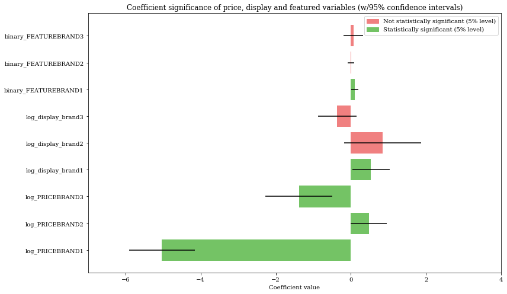

```python
#use estimate_ols function from `utils.py`, this will save the output to the '../results/' folder
brand1_model1_train = estimate_ols(target_col='log_UNITSBRAND1',
                                   feature_cols=model1_features,
                                   df=train,
                                   model_name='brand1_model1_train')

#save result to results dictionary
model_validation_results['brand1_model1'] = {}
model_validation_results['brand1_model1']['r2'] = brand1_model1_train.rsquared

print(brand1_model1_train.summary())
print("\n"*2)
plot_coef_conf_int(brand1_model1_train)
plt.savefig(f"{VISUALISATION_FOLDER}/brand1_model1_train_significance.png")
plt.show()
```

The model provides a relatively good fit for the data with an $R^{2}$ of 0.792 indicating that 79% of the variation in the unit sales of brand 1 is captured by the model.

#### Model Diagnostics

Evaluate the diagnostic plots for the regression models to check OLS assumptions

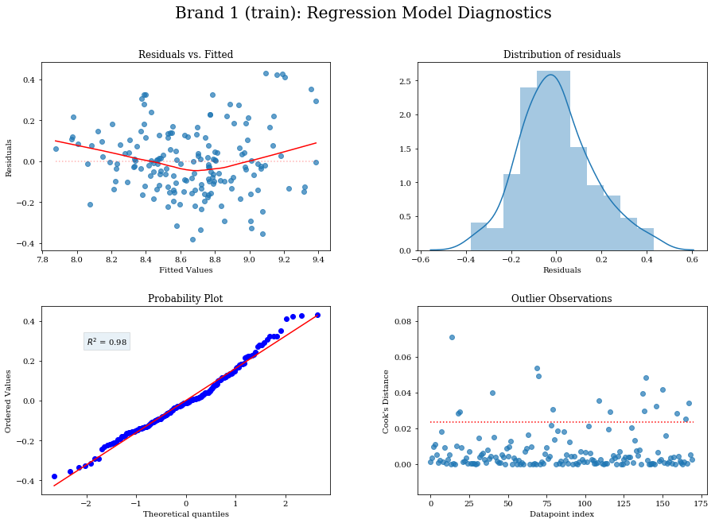

```python
plot_diagnostics(brand1_model1_train, "Brand 1 (train)")
plt.savefig(f"{VISUALISATION_FOLDER}/brand1_model1_train_diagnostics.png")
plt.show()
```

The residuals appear to be randomly and normally distributed.

#### Model Validation

```
RMSE = 0.1659
```

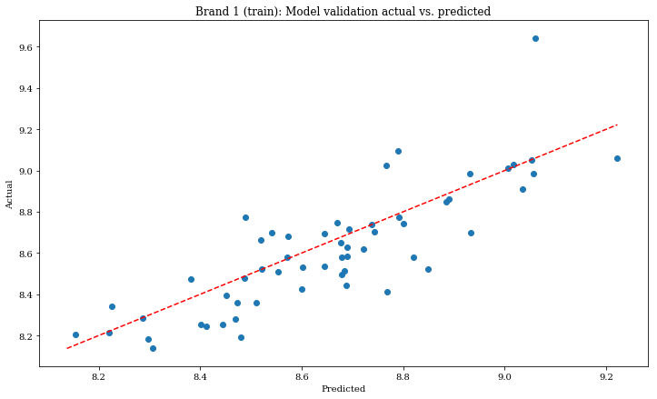

```python
preds = brand1_model1_train.predict(sm.add_constant(test[model1_features]))

rmse = mean_squared_error(test['log_UNITSBRAND1'],preds)**0.5
model_validation_results['brand1_model1']['rmse'] = rmse

print(f"RMSE = {round(rmse,4)}")

plot_preds_versus_actual(preds,test['log_UNITSBRAND1'], "Brand 1 (train)")
plt.savefig(f"{VISUALISATION_FOLDER}/brand1_model1_train_val.png")
plt.show()
```

### Brand 2

#### Model Estimation

```
                            OLS Regression Results
==============================================================================
Dep. Variable:        log_UNITSBRAND2   R-squared:                       0.813
Model:                            OLS   Adj. R-squared:                  0.788
Method:                 Least Squares   F-statistic:                     32.35
Date:                Fri, 17 Apr 2020   Prob (F-statistic):           3.38e-44
Time:                        15:35:17   Log-Likelihood:                 90.869
No. Observations:                 170   AIC:                            -139.7
Df Residuals:                     149   BIC:                            -73.89
Df Model:                          20
Covariance Type:            nonrobust
========================================================================================
                           coef    std err          t      P>|t|      [0.025      0.975]
----------------------------------------------------------------------------------------
const                   16.5339      1.123     14.718      0.000      14.314      18.754
log_PRICEBRAND1         -0.3958      0.391     -1.013      0.313      -1.168       0.376
log_PRICEBRAND2         -3.5441      0.215    -16.506      0.000      -3.968      -3.120
log_PRICEBRAND3         -0.7798      0.398     -1.961      0.052      -1.566       0.006
log_display_brand1      -0.0666      0.220     -0.303      0.763      -0.502       0.368
log_display_brand2       2.3675      0.458      5.165      0.000       1.462       3.273
log_display_brand3      -0.4222      0.228     -1.849      0.066      -0.874       0.029
binary_FEATUREBRAND1     0.0219      0.042      0.517      0.606      -0.062       0.105
binary_FEATUREBRAND2     0.0290      0.040      0.732      0.465      -0.049       0.107
binary_FEATUREBRAND3     0.0605      0.117      0.518      0.605      -0.170       0.291
August                   0.1475      0.057      2.592      0.010       0.035       0.260
December                -0.0853      0.065     -1.307      0.193      -0.214       0.044
February                -0.1629      0.060     -2.702      0.008      -0.282      -0.044
January                 -0.1397      0.059     -2.363      0.019      -0.257      -0.023
July                     0.1657      0.059      2.827      0.005       0.050       0.282
June                     0.2516      0.060      4.212      0.000       0.134       0.370
March                   -0.0336      0.060     -0.558      0.577      -0.152       0.085
May                      0.2415      0.060      4.049      0.000       0.124       0.359
November                -0.1138      0.062     -1.835      0.068      -0.236       0.009
October                 -0.0950      0.062     -1.539      0.126      -0.217       0.027
September               -0.0029      0.064     -0.045      0.964      -0.129       0.123
==============================================================================
Omnibus:                        5.318   Durbin-Watson:                   2.074
Prob(Omnibus):                  0.070   Jarque-Bera (JB):                4.876
Skew:                           0.383   Prob(JB):                       0.0873
Kurtosis:                       3.320   Cond. No.                         330.
==============================================================================

Warnings:
[1] Standard Errors assume that the covariance matrix of the errors is correctly specified.
```

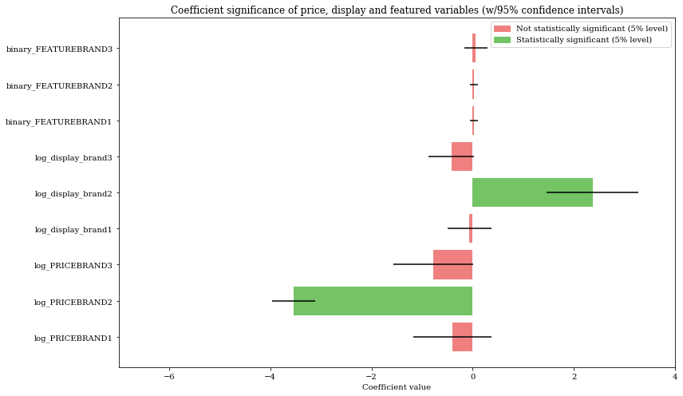

```python
#use estimate_ols function from `utils.py`, this will save the output to the '../results/' folder
brand2_model1_train = estimate_ols(target_col='log_UNITSBRAND2',
                                   feature_cols=model1_features,
                                   df=train,
                                   model_name='brand2_model1_train')

#save result to results dictionary
model_validation_results['brand2_model1'] = {}
model_validation_results['brand2_model1']['r2'] = brand2_model1_train.rsquared

print(brand2_model1_train.summary())
print("\n"*2)
plot_coef_conf_int(brand2_model1_train)
plt.savefig(f"{VISUALISATION_FOLDER}/brand2_model1_train_significance.png")
plt.show()
```

#### Model Diagnostics

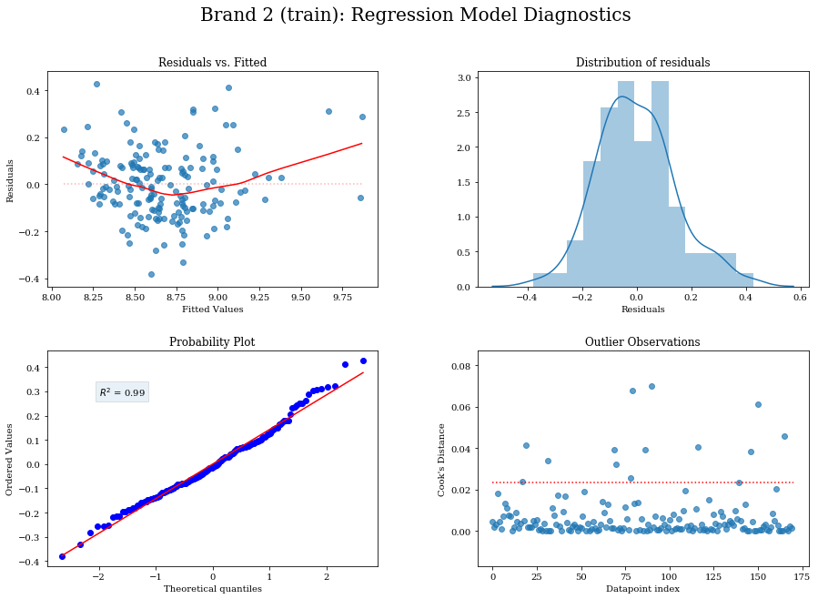

```python
plot_diagnostics(brand2_model1_train, "Brand 2 (train)")
plt.savefig(f"{VISUALISATION_FOLDER}/brand2_model1_train_diagnostics.png")
plt.show()
```

#### Model Validation

```
RMSE = 0.172
```

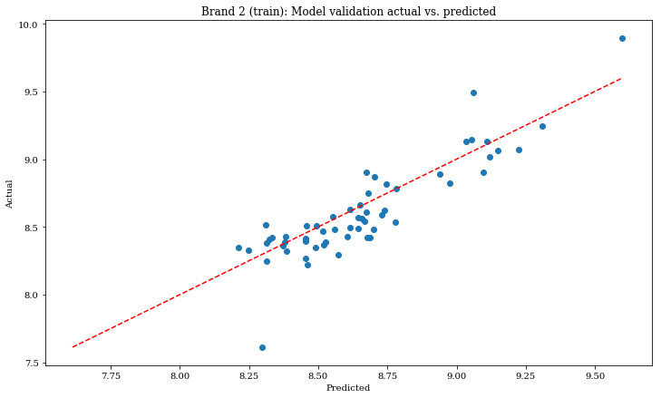

```python
preds = brand2_model1_train.predict(sm.add_constant(test[model1_features]))

rmse = mean_squared_error(test['log_UNITSBRAND2'],preds)**0.5
model_validation_results['brand2_model1']['rmse'] = rmse

print(f"RMSE = {round(rmse,4)}")

plot_preds_versus_actual(preds,test['log_UNITSBRAND2'], "Brand 2 (train)")
plt.savefig(f"{VISUALISATION_FOLDER}/brand2_model1_train_val.png")
plt.show()
```

### Brand 3

#### Model Estimation

```
                            OLS Regression Results
==============================================================================
Dep. Variable:        log_UNITSBRAND3   R-squared:                       0.814
Model:                            OLS   Adj. R-squared:                  0.789
Method:                 Least Squares   F-statistic:                     32.60
Date:                Fri, 17 Apr 2020   Prob (F-statistic):           2.14e-44
Time:                        15:35:19   Log-Likelihood:                 81.306
No. Observations:                 170   AIC:                            -120.6
Df Residuals:                     149   BIC:                            -54.76
Df Model:                          20
Covariance Type:            nonrobust
========================================================================================
                           coef    std err          t      P>|t|      [0.025      0.975]
----------------------------------------------------------------------------------------
const                   14.9059      1.188     12.543      0.000      12.558      17.254
log_PRICEBRAND1          0.6168      0.413      1.493      0.138      -0.200       1.433
log_PRICEBRAND2          1.1439      0.227      5.036      0.000       0.695       1.593
log_PRICEBRAND3         -6.2676      0.421    -14.897      0.000      -7.099      -5.436
log_display_brand1       0.2389      0.233      1.026      0.307      -0.221       0.699
log_display_brand2       1.4226      0.485      2.934      0.004       0.465       2.381
log_display_brand3      -0.6383      0.242     -2.642      0.009      -1.116      -0.161
binary_FEATUREBRAND1     0.0030      0.045      0.068      0.946      -0.085       0.091
binary_FEATUREBRAND2    -0.0110      0.042     -0.263      0.793      -0.094       0.072
binary_FEATUREBRAND3     0.1229      0.123      0.996      0.321      -0.121       0.367
August                   0.2187      0.060      3.632      0.000       0.100       0.338
December                -0.1266      0.069     -1.834      0.069      -0.263       0.010
February                -0.1360      0.064     -2.133      0.035      -0.262      -0.010
January                 -0.0754      0.063     -1.205      0.230      -0.199       0.048
July                     0.2673      0.062      4.311      0.000       0.145       0.390
June                     0.2885      0.063      4.565      0.000       0.164       0.413
March                   -0.0814      0.064     -1.280      0.203      -0.207       0.044
May                      0.2322      0.063      3.680      0.000       0.108       0.357
November                -0.0820      0.066     -1.250      0.213      -0.212       0.048
October                 -0.0338      0.065     -0.517      0.606      -0.163       0.095
September                0.1077      0.067      1.596      0.113      -0.026       0.241
==============================================================================
Omnibus:                        5.401   Durbin-Watson:                   1.949
Prob(Omnibus):                  0.067   Jarque-Bera (JB):                5.058
Skew:                           0.346   Prob(JB):                       0.0797
Kurtosis:                       3.485   Cond. No.                         330.
==============================================================================

Warnings:
[1] Standard Errors assume that the covariance matrix of the errors is correctly specified.
```

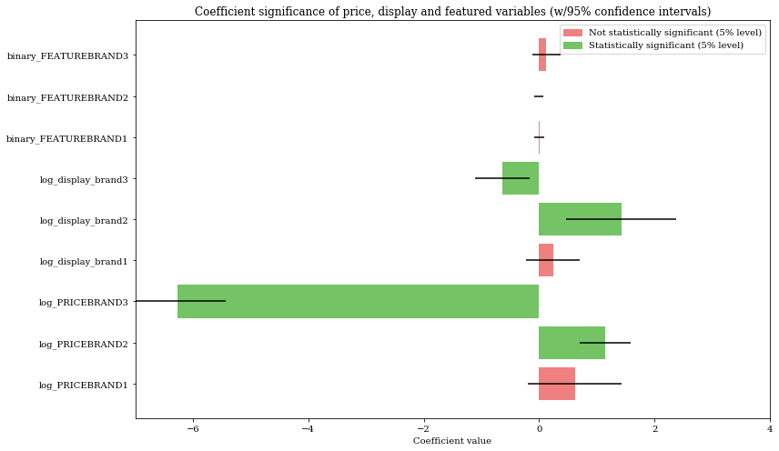

```python
#use estimate_ols function from `utils.py`, this will save the output to the '../results/' folder
brand3_model1_train = estimate_ols(target_col='log_UNITSBRAND3',
                                   feature_cols=model1_features,
                                   df=train,
                                   model_name='brand3_model1_train')

#save result to results dictionary
model_validation_results['brand3_model1'] = {}
model_validation_results['brand3_model1']['r2'] = brand3_model1_train.rsquared

print(brand3_model1_train.summary())
print("\n"*2)
plot_coef_conf_int(brand3_model1_train)
plt.savefig(f"{VISUALISATION_FOLDER}/brand3_model1_train_significance.png")
plt.show()
```

#### Model Diagnostics

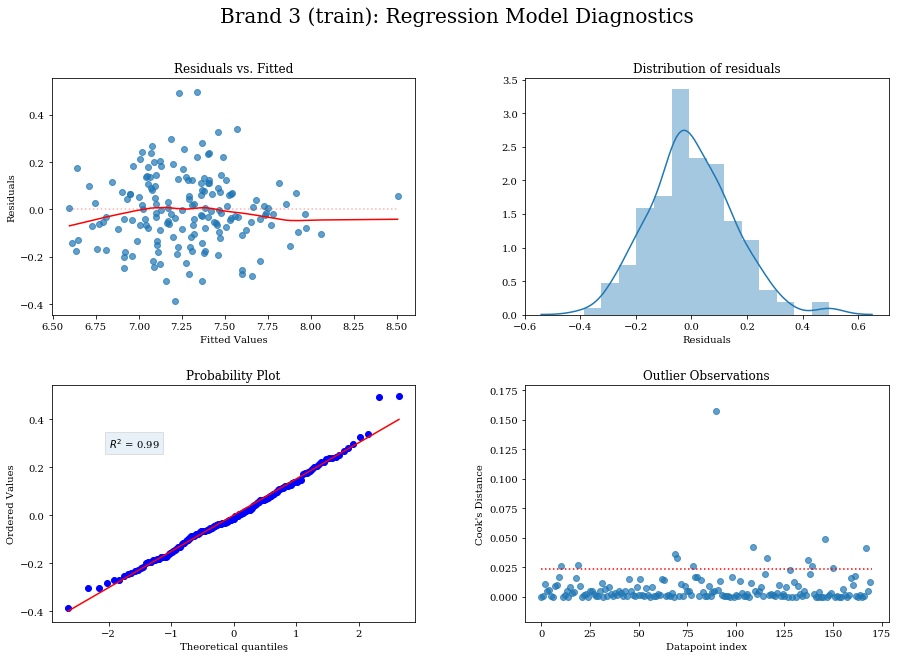

```python
plot_diagnostics(brand3_model1_train, "Brand 3 (train)")
plt.savefig(f"{VISUALISATION_FOLDER}/brand3_model1_train_diagnostics.png")
plt.show()
```

#### Model Validation

```
RMSE = 0.1774
```

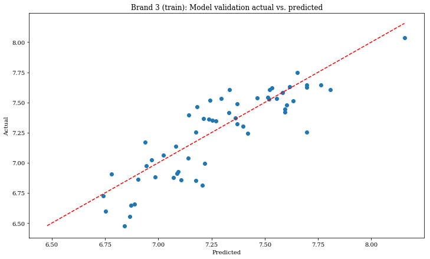

```python
preds = brand3_model1_train.predict(sm.add_constant(test[model1_features]))

rmse = mean_squared_error(test['log_UNITSBRAND3'],preds)**0.5
model_validation_results['brand3_model1']['rmse'] = rmse

print(f"RMSE = {round(rmse,4)}")

plot_preds_versus_actual(preds,test['log_UNITSBRAND3'], "Brand 3 (train)")
plt.savefig(f"{VISUALISATION_FOLDER}/brand3_model1_train_val.png")
plt.show()
```

### Train/validation conclusions

```python
model_validation_results
```

```
{'brand1_model1': {'r2': 0.7922329663848333, 'rmse': 0.16593977008800298},
 'brand2_model1': {'r2': 0.8128036918712811, 'rmse': 0.1720202024583431},
 'brand3_model1': {'r2': 0.8139893257702171, 'rmse': 0.17737488512589342}}
```

All three models show a good fit for the data ($R^2$ ~ 0.8), diagnostic plots which confirm regression normality and heteroskedasticity assumptions, and give reasonable predictions on the unseen test data sets. Therefore, we can conclude that the model with seasonal dummy variables and binary featured variables is an appropriate and good model to estimate units sales of beer for each brand.

```python
validation_results_df = pd.DataFrame(model_validation_results).T
validation_results_df.index = ['Brand 1','Brand 2', 'Brand 3']
Latex(validation_results_df.to_latex())
```

\begin{tabular}{lrr} \toprule {} & r2 & rmse \\ \midrule Brand 1 & 0.792233 & 0.165940 \\ Brand 2 & 0.812804 & 0.172020 \\ Brand 3 & 0.813989 & 0.177375 \\ \bottomrule \end{tabular}

## Final Models

Before interpreting the coefficients of the models, each regression model will be retrained on all the data.

**Retrain on all data**

```python
brand1_modelfinal = estimate_ols(target_col='log_UNITSBRAND1',
                                 feature_cols=model1_features,
                                 df=data, #use all data
                                 model_name='brand1_modelfinal')

brand2_modelfinal = estimate_ols(target_col='log_UNITSBRAND2',
                                 feature_cols=model1_features,
                                 df=data, #use all data
                                 model_name='brand2_modelfinal')

brand3_modelfinal = estimate_ols(target_col='log_UNITSBRAND3',
                                 feature_cols=model1_features,
                                 df=data, #use all data
                                 model_name='brand3_modelfinal')
```

```python
final_model_results = {}
```

### Brand 1

```
                            OLS Regression Results
==============================================================================
Dep. Variable:        log_UNITSBRAND1   R-squared:                       0.777
Model:                            OLS   Adj. R-squared:                  0.756
Method:                 Least Squares   F-statistic:                     35.96
Date:                Fri, 17 Apr 2020   Prob (F-statistic):           3.77e-56
Time:                        15:35:24   Log-Likelihood:                 94.246
No. Observations:                 227   AIC:                            -146.5
Df Residuals:                     206   BIC:                            -74.57
Df Model:                          20
Covariance Type:            nonrobust
========================================================================================
                           coef    std err          t      P>|t|      [0.025      0.975]
----------------------------------------------------------------------------------------
const                   18.8007      1.033     18.206      0.000      16.765      20.837
log_PRICEBRAND1         -4.8740      0.369    -13.209      0.000      -5.601      -4.146
log_PRICEBRAND2          0.3262      0.205      1.589      0.114      -0.079       0.731
log_PRICEBRAND3         -1.4018      0.362     -3.873      0.000      -2.115      -0.688
log_display_brand1       0.6736      0.199      3.390      0.001       0.282       1.065
log_display_brand2       0.7605      0.414      1.837      0.068      -0.056       1.577
log_display_brand3      -0.3266      0.215     -1.521      0.130      -0.750       0.097
binary_FEATUREBRAND1     0.0939      0.040      2.376      0.018       0.016       0.172
binary_FEATUREBRAND2     0.0075      0.042      0.179      0.858      -0.075       0.090
binary_FEATUREBRAND3     0.0148      0.107      0.138      0.890      -0.196       0.225
August                   0.2292      0.057      4.019      0.000       0.117       0.342
December                -0.0772      0.061     -1.266      0.207      -0.198       0.043
February                -0.1557      0.059     -2.625      0.009      -0.273      -0.039
January                 -0.0700      0.060     -1.174      0.242      -0.188       0.048
July                     0.2674      0.056      4.737      0.000       0.156       0.379
June                     0.3694      0.059      6.304      0.000       0.254       0.485
March                   -0.1076      0.060     -1.796      0.074      -0.226       0.011
May                      0.3299      0.058      5.658      0.000       0.215       0.445
November                -0.0992      0.061     -1.633      0.104      -0.219       0.021
October                 -0.0726      0.058     -1.244      0.215      -0.188       0.042
September                0.0766      0.055      1.383      0.168      -0.033       0.186
==============================================================================
Omnibus:                       11.282   Durbin-Watson:                   1.446
Prob(Omnibus):                  0.004   Jarque-Bera (JB):               11.511
Skew:                           0.520   Prob(JB):                      0.00317
Kurtosis:                       3.366   Cond. No.                         317.
==============================================================================

Warnings:
[1] Standard Errors assume that the covariance matrix of the errors is correctly specified.
```

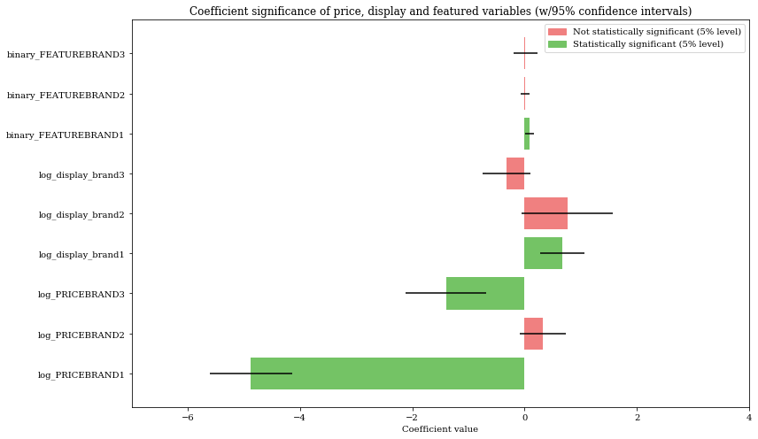

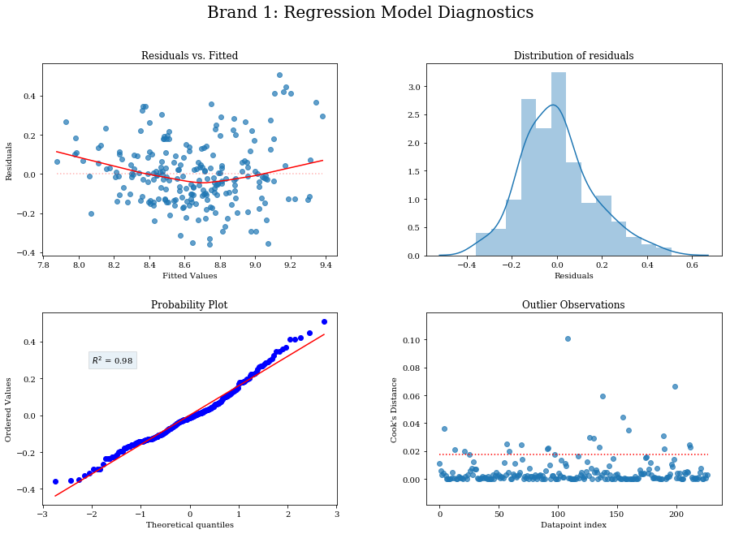

```python
#save result to results dictionary
final_model_results['brand1'] = {}
final_model_results['brand1']['r2'] = brand1_modelfinal.rsquared

print(brand1_modelfinal.summary())
print("\n"*2)
plot_coef_conf_int(brand1_modelfinal)
plt.savefig(f"{VISUALISATION_FOLDER}/brand1_modelfinal_significance.png")
plt.show()

plot_diagnostics(brand1_modelfinal, "Brand 1")
plt.savefig(f"{VISUALISATION_FOLDER}/brand1_modelfinal_diagnostics.png")
plt.show()
```

**Price**

**display**

Only `log_display_brand1` is statistically significant for the `display` variables. Therefore, whether brand 2 or 3 are on display has no effect on the unit sales of brand 1. The `display` variable is expressed as a percentage of stock keeping units (SKUs), therefore the coefficient of 0.67 for `log_display_brand1` can be interpreted as meaning that if the percentage of SKUs on display of brand 1 are increased by 1% (note this is not the same as an increase in SKU by 1 *percentage point*) then the unit sales can be expected to increase by 0.67%.

**Feature**

Only `binary_FEATUREBRAND1` is statistically significant for the `FEATURE` variables. The magnitude of the coefficient is 0.0939. As this is a *binary* variable and the target column was created using a log(x+1) transformation, the coefficient value is actually interpreted as being $e^{coefficient}$ i.e. $e^{0.0939}$ = 1.0984. This means that if the brand 1 is featured in a particular week (i.e. binary_FEATUREBRAND1 = 1), then unit sales can be expected to increase by 9.84%.

### Brand 2

```
                            OLS Regression Results
==============================================================================
Dep. Variable:        log_UNITSBRAND2   R-squared:                       0.805
Model:                            OLS   Adj. R-squared:                  0.786
Method:                 Least Squares   F-statistic:                     42.52
Date:                Fri, 17 Apr 2020   Prob (F-statistic):           6.01e-62
Time:                        15:35:25   Log-Likelihood:                 111.22
No. Observations:                 227   AIC:                            -180.4
Df Residuals:                     206   BIC:                            -108.5
Df Model:                          20
Covariance Type:            nonrobust
========================================================================================
                           coef    std err          t      P>|t|      [0.025      0.975]
----------------------------------------------------------------------------------------
const                   16.6887      0.958     17.416      0.000      14.799      18.578
log_PRICEBRAND1         -0.5023      0.342     -1.467      0.144      -1.177       0.173
log_PRICEBRAND2         -3.6822      0.190    -19.329      0.000      -4.058      -3.307
log_PRICEBRAND3         -0.6435      0.336     -1.916      0.057      -1.306       0.019
log_display_brand1      -0.1127      0.184     -0.611      0.542      -0.476       0.251
log_display_brand2       2.5825      0.384      6.724      0.000       1.825       3.340
log_display_brand3      -0.3336      0.199     -1.675      0.095      -0.726       0.059
binary_FEATUREBRAND1     0.0152      0.037      0.414      0.679      -0.057       0.087
binary_FEATUREBRAND2     0.0325      0.039      0.841      0.401      -0.044       0.109
binary_FEATUREBRAND3     0.0320      0.099      0.323      0.747      -0.163       0.227
August                   0.1409      0.053      2.662      0.008       0.037       0.245
December                -0.0739      0.057     -1.306      0.193      -0.186       0.038
February                -0.1645      0.055     -2.989      0.003      -0.273      -0.056
January                 -0.1237      0.055     -2.235      0.027      -0.233      -0.015
July                     0.1566      0.052      2.989      0.003       0.053       0.260
June                     0.2464      0.054      4.531      0.000       0.139       0.354
March                   -0.0576      0.056     -1.035      0.302      -0.167       0.052
May                      0.2229      0.054      4.121      0.000       0.116       0.330
November                -0.0993      0.056     -1.761      0.080      -0.211       0.012
October                 -0.1148      0.054     -2.119      0.035      -0.222      -0.008
September               -0.0330      0.051     -0.642      0.522      -0.134       0.068
==============================================================================
Omnibus:                        8.722   Durbin-Watson:                   1.414
Prob(Omnibus):                  0.013   Jarque-Bera (JB):               16.292
Skew:                           0.071   Prob(JB):                     0.000290
Kurtosis:                       4.305   Cond. No.                         317.
==============================================================================

Warnings:
[1] Standard Errors assume that the covariance matrix of the errors is correctly specified.
```

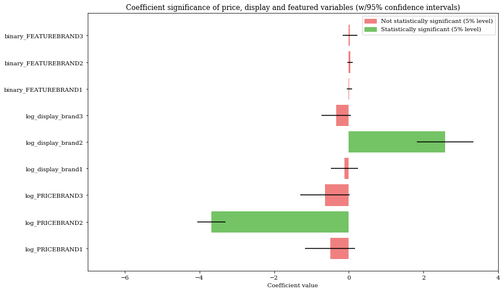

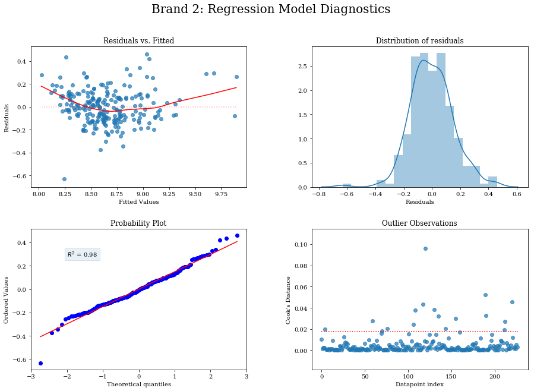

```python
#save result to results dictionary
final_model_results['brand2'] = {}
final_model_results['brand2']['r2'] = brand2_modelfinal.rsquared

print(brand2_modelfinal.summary())
print("\n"*2)
plot_coef_conf_int(brand2_modelfinal)
plt.savefig(f"{VISUALISATION_FOLDER}/brand2_modelfinal_significance.png")
plt.show()

plot_diagnostics(brand2_modelfinal, "Brand 2")
plt.savefig(f"{VISUALISATION_FOLDER}/brand2_modelfinal_diagnostics.png")
plt.show()
```

**Price**

**display**

**Feature**

None of the 'FEATURE' variables are statistically significant in the regression model for brand 2 unit sales. It would be expected that featuring brand 2 would increase its sales. The coefficient for `binary_FEATUREBRAND2` is 0.0325, however, the p value is extremely high (0.401) so we cannot reject the null hypothesis that the coefficient is 0 and there is no effect on sales when brand 2 is featured. `binary_FEATUREBRAND1` and `binary_FEATUREBRAND3` are also statistically insignificant with very high p values (0.679 and 0.747) so we can say that there is no effect on brand 2 sales if brand 1 or brand 3 are featured in that week.

### Brand 3

```
                            OLS Regression Results
==============================================================================
Dep. Variable:        log_UNITSBRAND3   R-squared:                       0.802
Model:                            OLS   Adj. R-squared:                  0.783
Method:                 Least Squares   F-statistic:                     41.69
Date:                Fri, 17 Apr 2020   Prob (F-statistic):           2.92e-61
Time:                        15:35:27   Log-Likelihood:                 100.73
No. Observations:                 227   AIC:                            -159.5
Df Residuals:                     206   BIC:                            -87.53
Df Model:                          20
Covariance Type:            nonrobust
========================================================================================
                           coef    std err          t      P>|t|      [0.025      0.975]
----------------------------------------------------------------------------------------
const                   14.9740      1.004     14.920      0.000      12.995      16.953
log_PRICEBRAND1          0.4840      0.359      1.350      0.179      -0.223       1.191
log_PRICEBRAND2          1.0858      0.200      5.442      0.000       0.692       1.479
log_PRICEBRAND3         -6.1407      0.352    -17.455      0.000      -6.834      -5.447
log_display_brand1       0.1762      0.193      0.912      0.363      -0.205       0.557
log_display_brand2       1.5551      0.402      3.866      0.000       0.762       2.348
log_display_brand3      -0.4286      0.209     -2.055      0.041      -0.840      -0.017
binary_FEATUREBRAND1     0.0125      0.038      0.326      0.745      -0.063       0.088
binary_FEATUREBRAND2    -0.0133      0.040     -0.328      0.743      -0.093       0.067
binary_FEATUREBRAND3     0.1231      0.104      1.186      0.237      -0.082       0.328
August                   0.2225      0.055      4.016      0.000       0.113       0.332
December                -0.0903      0.059     -1.522      0.129      -0.207       0.027
February                -0.1031      0.058     -1.789      0.075      -0.217       0.011
January                 -0.0728      0.058     -1.256      0.210      -0.187       0.041
July                     0.2690      0.055      4.903      0.000       0.161       0.377
June                     0.2794      0.057      4.906      0.000       0.167       0.392
March                   -0.1100      0.058     -1.888      0.060      -0.225       0.005
May                      0.2266      0.057      3.998      0.000       0.115       0.338
November                -0.0538      0.059     -0.911      0.364      -0.170       0.063
October                 -0.0464      0.057     -0.818      0.415      -0.158       0.065
September                0.1006      0.054      1.869      0.063      -0.006       0.207
==============================================================================
Omnibus:                        3.704   Durbin-Watson:                   1.106
Prob(Omnibus):                  0.157   Jarque-Bera (JB):                3.343
Skew:                           0.244   Prob(JB):                        0.188
Kurtosis:                       3.339   Cond. No.                         317.
==============================================================================

Warnings:
[1] Standard Errors assume that the covariance matrix of the errors is correctly specified.
```

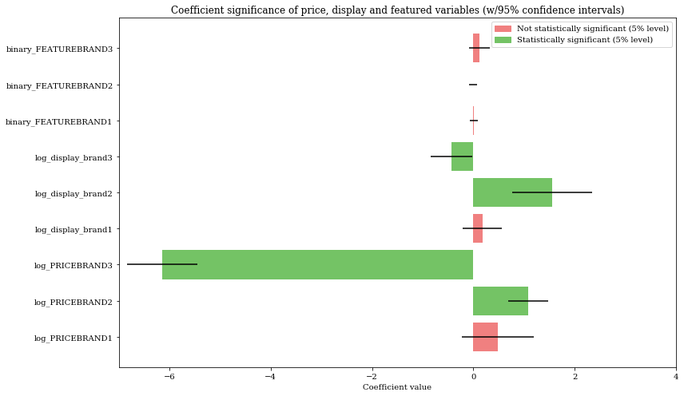

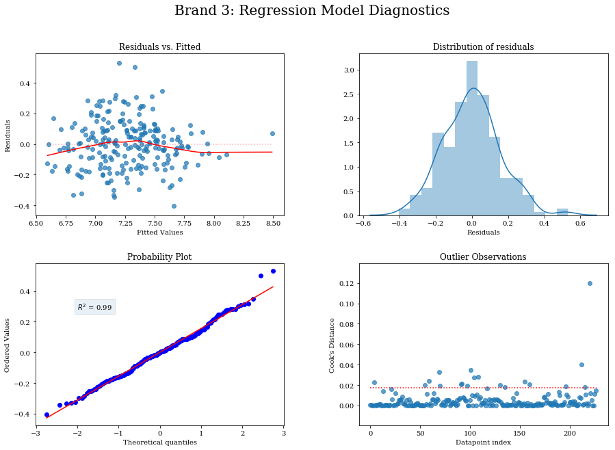

```python
#save result to results dictionary
final_model_results['brand3'] = {}
final_model_results['brand3']['r2'] = brand3_modelfinal.rsquared

print(brand3_modelfinal.summary())
print("\n"*2)
plot_coef_conf_int(brand3_modelfinal)
plt.savefig(f"{VISUALISATION_FOLDER}/brand3_modelfinal_significance.png")
plt.show()

plot_diagnostics(brand3_modelfinal, "Brand 3")
plt.savefig(f"{VISUALISATION_FOLDER}/brand3_modelfinal_diagnostics.png")
plt.show()
```

**Price**

The coefficient of `log_PRICEBRAND3` can be interpreted as meaning that if the price of brand 3 is reduced by 1%, unit sales will increase by 6.14%.

**display**

`log_display_brand3` has a coefficient of -0.4286 which is statistically significant, however, there is a relatively large error boundary which reaches an upper level of -0.017. This suggests that displaying more stock keeping units of brand 3 actually decreases the unit sales. The coefficient for `log_display_brand2` shows that if more of brand 2 is displayed unit sales of brand 3 will increase.

**Feature**

Once again, none of the 'FEATURE' variables are statistically significant in the regression model for brand 3 unit sales. The `binary_FEATUREBRAND3` coefficient is 0.1231 with a p value of 0.237. Even though the confidence in this coefficient is low and we cannot reject the null hypothesis, it would imply that if brand 3 is featured it would increase unit sales by 13.1% ($e^{0.1231)$ = 1.1310).

```python
brand_params = {}

for i, model in zip([1,2,3],[brand1_modelfinal,brand2_modelfinal,brand3_modelfinal]):
    brand_params[f'brand{i}'] = {}
    brand_params[f'brand{i}']['log_PRICE'] = model.params[f'log_PRICEBRAND{i}']
    brand_params[f'brand{i}']['log_display'] = model.params[f'log_display_brand{i}']
    brand_params[f'brand{i}']['binary_FEATURE'] = np.exp(model.params[f'binary_FEATUREBRAND{i}'])
```

```python
pd.DataFrame(brand_params)
```

|  | brand1 | brand2 | brand3 |
| --- | --- | --- | --- |
| binary_FEATURE | 1.098416 | 1.033053 | 1.131044 |
| log_PRICE | -4.873988 | -3.682217 | -6.140676 |
| log_display | 0.673647 | 2.582541 | -0.428605 |

# Latex Outputs For Report

Copy and paste output into the report

```python
display(HTML("<h3>Brand 1</h3>"))
Latex(brand1_modelfinal.summary().as_latex())
```

Brand 1

\begin{center} \begin{tabular}{lclc} \toprule \textbf{Dep. Variable:} & log\_UNITSBRAND1 & \textbf{ R-squared: } & 0.777 \\ \textbf{Model:} & OLS & \textbf{ Adj. R-squared: } & 0.756 \\ \textbf{Method:} & Least Squares & \textbf{ F-statistic: } & 35.96 \\ \textbf{Date:} & Fri, 17 Apr 2020 & \textbf{ Prob (F-statistic):} & 3.77e-56 \\ \textbf{Time:} & 15:35:29 & \textbf{ Log-Likelihood: } & 94.246 \\ \textbf{No. Observations:} & 227 & \textbf{ AIC: } & -146.5 \\ \textbf{Df Residuals:} & 206 & \textbf{ BIC: } & -74.57 \\ \textbf{Df Model:} & 20 & \textbf{ } & \\ \bottomrule \end{tabular} \begin{tabular}{lcccccc} & \textbf{coef} & \textbf{std err} & \textbf{t} & \textbf{P$> |$t$|$} & \textbf{[0.025} & \textbf{0.975]} \\ \midrule \textbf{const} & 18.8007 & 1.033 & 18.206 & 0.000 & 16.765 & 20.837 \\ \textbf{log\_PRICEBRAND1} & -4.8740 & 0.369 & -13.209 & 0.000 & -5.601 & -4.146 \\ \textbf{log\_PRICEBRAND2} & 0.3262 & 0.205 & 1.589 & 0.114 & -0.079 & 0.731 \\ \textbf{log\_PRICEBRAND3} & -1.4018 & 0.362 & -3.873 & 0.000 & -2.115 & -0.688 \\ \textbf{log\_display\_brand1} & 0.6736 & 0.199 & 3.390 & 0.001 & 0.282 & 1.065 \\ \textbf{log\_display\_brand2} & 0.7605 & 0.414 & 1.837 & 0.068 & -0.056 & 1.577 \\ \textbf{log\_display\_brand3} & -0.3266 & 0.215 & -1.521 & 0.130 & -0.750 & 0.097 \\ \textbf{binary\_FEATUREBRAND1} & 0.0939 & 0.040 & 2.376 & 0.018 & 0.016 & 0.172 \\ \textbf{binary\_FEATUREBRAND2} & 0.0075 & 0.042 & 0.179 & 0.858 & -0.075 & 0.090 \\ \textbf{binary\_FEATUREBRAND3} & 0.0148 & 0.107 & 0.138 & 0.890 & -0.196 & 0.225 \\ \textbf{August} & 0.2292 & 0.057 & 4.019 & 0.000 & 0.117 & 0.342 \\ \textbf{December} & -0.0772 & 0.061 & -1.266 & 0.207 & -0.198 & 0.043 \\ \textbf{February} & -0.1557 & 0.059 & -2.625 & 0.009 & -0.273 & -0.039 \\ \textbf{January} & -0.0700 & 0.060 & -1.174 & 0.242 & -0.188 & 0.048 \\ \textbf{July} & 0.2674 & 0.056 & 4.737 & 0.000 & 0.156 & 0.379 \\ \textbf{June} & 0.3694 & 0.059 & 6.304 & 0.000 & 0.254 & 0.485 \\ \textbf{March} & -0.1076 & 0.060 & -1.796 & 0.074 & -0.226 & 0.011 \\ \textbf{May} & 0.3299 & 0.058 & 5.658 & 0.000 & 0.215 & 0.445 \\ \textbf{November} & -0.0992 & 0.061 & -1.633 & 0.104 & -0.219 & 0.021 \\ \textbf{October} & -0.0726 & 0.058 & -1.244 & 0.215 & -0.188 & 0.042 \\ \textbf{September} & 0.0766 & 0.055 & 1.383 & 0.168 & -0.033 & 0.186 \\ \bottomrule \end{tabular} \begin{tabular}{lclc} \textbf{Omnibus:} & 11.282 & \textbf{ Durbin-Watson: } & 1.446 \\ \textbf{Prob(Omnibus):} & 0.004 & \textbf{ Jarque-Bera (JB): } & 11.511 \\ \textbf{Skew:} & 0.520 & \textbf{ Prob(JB): } & 0.00317 \\ \textbf{Kurtosis:} & 3.366 & \textbf{ Cond. No. } & 317. \\ \bottomrule \end{tabular} %\caption{OLS Regression Results} \end{center} Warnings: \newline [1] Standard Errors assume that the covariance matrix of the errors is correctly specified.

```python
np.exp(0.3694)
```

```
1.4468662344346466
```

```python
display(HTML("<h3>Brand 2</h3>"))
Latex(brand2_modelfinal.summary().as_latex())
```

Brand 2

\begin{center} \begin{tabular}{lclc} \toprule \textbf{Dep. Variable:} & log\_UNITSBRAND2 & \textbf{ R-squared: } & 0.805 \\ \textbf{Model:} & OLS & \textbf{ Adj. R-squared: } & 0.786 \\ \textbf{Method:} & Least Squares & \textbf{ F-statistic: } & 42.52 \\ \textbf{Date:} & Fri, 17 Apr 2020 & \textbf{ Prob (F-statistic):} & 6.01e-62 \\ \textbf{Time:} & 15:35:29 & \textbf{ Log-Likelihood: } & 111.22 \\ \textbf{No. Observations:} & 227 & \textbf{ AIC: } & -180.4 \\ \textbf{Df Residuals:} & 206 & \textbf{ BIC: } & -108.5 \\ \textbf{Df Model:} & 20 & \textbf{ } & \\ \bottomrule \end{tabular} \begin{tabular}{lcccccc} & \textbf{coef} & \textbf{std err} & \textbf{t} & \textbf{P$> |$t$|$} & \textbf{[0.025} & \textbf{0.975]} \\ \midrule \textbf{const} & 16.6887 & 0.958 & 17.416 & 0.000 & 14.799 & 18.578 \\ \textbf{log\_PRICEBRAND1} & -0.5023 & 0.342 & -1.467 & 0.144 & -1.177 & 0.173 \\ \textbf{log\_PRICEBRAND2} & -3.6822 & 0.190 & -19.329 & 0.000 & -4.058 & -3.307 \\ \textbf{log\_PRICEBRAND3} & -0.6435 & 0.336 & -1.916 & 0.057 & -1.306 & 0.019 \\ \textbf{log\_display\_brand1} & -0.1127 & 0.184 & -0.611 & 0.542 & -0.476 & 0.251 \\ \textbf{log\_display\_brand2} & 2.5825 & 0.384 & 6.724 & 0.000 & 1.825 & 3.340 \\ \textbf{log\_display\_brand3} & -0.3336 & 0.199 & -1.675 & 0.095 & -0.726 & 0.059 \\ \textbf{binary\_FEATUREBRAND1} & 0.0152 & 0.037 & 0.414 & 0.679 & -0.057 & 0.087 \\ \textbf{binary\_FEATUREBRAND2} & 0.0325 & 0.039 & 0.841 & 0.401 & -0.044 & 0.109 \\ \textbf{binary\_FEATUREBRAND3} & 0.0320 & 0.099 & 0.323 & 0.747 & -0.163 & 0.227 \\ \textbf{August} & 0.1409 & 0.053 & 2.662 & 0.008 & 0.037 & 0.245 \\ \textbf{December} & -0.0739 & 0.057 & -1.306 & 0.193 & -0.186 & 0.038 \\ \textbf{February} & -0.1645 & 0.055 & -2.989 & 0.003 & -0.273 & -0.056 \\ \textbf{January} & -0.1237 & 0.055 & -2.235 & 0.027 & -0.233 & -0.015 \\ \textbf{July} & 0.1566 & 0.052 & 2.989 & 0.003 & 0.053 & 0.260 \\ \textbf{June} & 0.2464 & 0.054 & 4.531 & 0.000 & 0.139 & 0.354 \\ \textbf{March} & -0.0576 & 0.056 & -1.035 & 0.302 & -0.167 & 0.052 \\ \textbf{May} & 0.2229 & 0.054 & 4.121 & 0.000 & 0.116 & 0.330 \\ \textbf{November} & -0.0993 & 0.056 & -1.761 & 0.080 & -0.211 & 0.012 \\ \textbf{October} & -0.1148 & 0.054 & -2.119 & 0.035 & -0.222 & -0.008 \\ \textbf{September} & -0.0330 & 0.051 & -0.642 & 0.522 & -0.134 & 0.068 \\ \bottomrule \end{tabular} \begin{tabular}{lclc} \textbf{Omnibus:} & 8.722 & \textbf{ Durbin-Watson: } & 1.414 \\ \textbf{Prob(Omnibus):} & 0.013 & \textbf{ Jarque-Bera (JB): } & 16.292 \\ \textbf{Skew:} & 0.071 & \textbf{ Prob(JB): } & 0.000290 \\ \textbf{Kurtosis:} & 4.305 & \textbf{ Cond. No. } & 317. \\ \bottomrule \end{tabular} %\caption{OLS Regression Results} \end{center} Warnings: \newline [1] Standard Errors assume that the covariance matrix of the errors is correctly specified.

```python
display(HTML("<h3>Brand 3</h3>"))
Latex(brand3_modelfinal.summary().as_latex())
```

Brand 3

\begin{center} \begin{tabular}{lclc} \toprule \textbf{Dep. Variable:} & log\_UNITSBRAND3 & \textbf{ R-squared: } & 0.802 \\ \textbf{Model:} & OLS & \textbf{ Adj. R-squared: } & 0.783 \\ \textbf{Method:} & Least Squares & \textbf{ F-statistic: } & 41.69 \\ \textbf{Date:} & Fri, 17 Apr 2020 & \textbf{ Prob (F-statistic):} & 2.92e-61 \\ \textbf{Time:} & 15:35:29 & \textbf{ Log-Likelihood: } & 100.73 \\ \textbf{No. Observations:} & 227 & \textbf{ AIC: } & -159.5 \\ \textbf{Df Residuals:} & 206 & \textbf{ BIC: } & -87.53 \\ \textbf{Df Model:} & 20 & \textbf{ } & \\ \bottomrule \end{tabular} \begin{tabular}{lcccccc} & \textbf{coef} & \textbf{std err} & \textbf{t} & \textbf{P$> |$t$|$} & \textbf{[0.025} & \textbf{0.975]} \\ \midrule \textbf{const} & 14.9740 & 1.004 & 14.920 & 0.000 & 12.995 & 16.953 \\ \textbf{log\_PRICEBRAND1} & 0.4840 & 0.359 & 1.350 & 0.179 & -0.223 & 1.191 \\ \textbf{log\_PRICEBRAND2} & 1.0858 & 0.200 & 5.442 & 0.000 & 0.692 & 1.479 \\ \textbf{log\_PRICEBRAND3} & -6.1407 & 0.352 & -17.455 & 0.000 & -6.834 & -5.447 \\ \textbf{log\_display\_brand1} & 0.1762 & 0.193 & 0.912 & 0.363 & -0.205 & 0.557 \\ \textbf{log\_display\_brand2} & 1.5551 & 0.402 & 3.866 & 0.000 & 0.762 & 2.348 \\ \textbf{log\_display\_brand3} & -0.4286 & 0.209 & -2.055 & 0.041 & -0.840 & -0.017 \\ \textbf{binary\_FEATUREBRAND1} & 0.0125 & 0.038 & 0.326 & 0.745 & -0.063 & 0.088 \\ \textbf{binary\_FEATUREBRAND2} & -0.0133 & 0.040 & -0.328 & 0.743 & -0.093 & 0.067 \\ \textbf{binary\_FEATUREBRAND3} & 0.1231 & 0.104 & 1.186 & 0.237 & -0.082 & 0.328 \\ \textbf{August} & 0.2225 & 0.055 & 4.016 & 0.000 & 0.113 & 0.332 \\ \textbf{December} & -0.0903 & 0.059 & -1.522 & 0.129 & -0.207 & 0.027 \\ \textbf{February} & -0.1031 & 0.058 & -1.789 & 0.075 & -0.217 & 0.011 \\ \textbf{January} & -0.0728 & 0.058 & -1.256 & 0.210 & -0.187 & 0.041 \\ \textbf{July} & 0.2690 & 0.055 & 4.903 & 0.000 & 0.161 & 0.377 \\ \textbf{June} & 0.2794 & 0.057 & 4.906 & 0.000 & 0.167 & 0.392 \\ \textbf{March} & -0.1100 & 0.058 & -1.888 & 0.060 & -0.225 & 0.005 \\ \textbf{May} & 0.2266 & 0.057 & 3.998 & 0.000 & 0.115 & 0.338 \\ \textbf{November} & -0.0538 & 0.059 & -0.911 & 0.364 & -0.170 & 0.063 \\ \textbf{October} & -0.0464 & 0.057 & -0.818 & 0.415 & -0.158 & 0.065 \\ \textbf{September} & 0.1006 & 0.054 & 1.869 & 0.063 & -0.006 & 0.207 \\ \bottomrule \end{tabular} \begin{tabular}{lclc} \textbf{Omnibus:} & 3.704 & \textbf{ Durbin-Watson: } & 1.106 \\ \textbf{Prob(Omnibus):} & 0.157 & \textbf{ Jarque-Bera (JB): } & 3.343 \\ \textbf{Skew:} & 0.244 & \textbf{ Prob(JB): } & 0.188 \\ \textbf{Kurtosis:} & 3.339 & \textbf{ Cond. No. } & 317. \\ \bottomrule \end{tabular} %\caption{OLS Regression Results} \end{center} Warnings: \newline [1] Standard Errors assume that the covariance matrix of the errors is correctly specified.